# Analysis of Hospitalization Rates

2022-12-19T19:15:51-05:00

In this section of the data analysis, we look more closely at the different demographics for asthma hospitalizations within California counties in order to notice major trends between different ages and racial groups.

First, we facet the data by age to get a sense of trends for each age group (kids ages 0-17 or adults 18+).

Faceted by Kids v. Adult: Age-Adjusted Hospitalization Rate by County and colored by County Open Park Area

Using the parks_athma_CA_kids_v_adults dataset, this plot shows that in general the age-adjusted hospitalization rate by county (which is the rate of hospitalizations for a county adjusted for the age group’s population in that county) is much higher for kids (0-17 years) than for adults (18+ years). As you can see from the plot, the highest hospitalization rate for adults is around 5, whereas the highest hospitalization rate for kids is above 15 and most of the counties have hospitalization rates for kids that are above 5. This tells us that, generally, kids have higher asthma hospitalization rates in every county. Perhaps this is partially because asthma prevalence is higher in children than adults, in general.

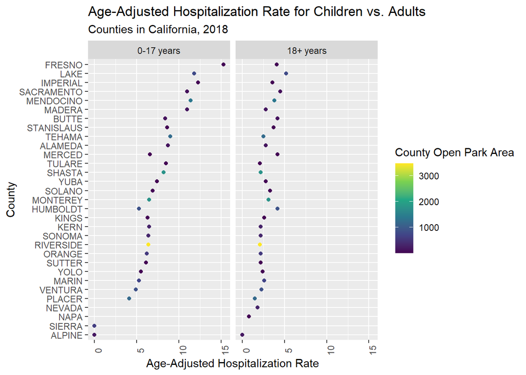

Next, we create maps (using a combination of the USAboundaries, sf, and tmap packages) to visualize the asthma hospitalization rates across different counties by each Race/Ethnicity. Since there was hardly any data for AI/AN category, we do not include it in our map. Note also: these maps were originally going to be featured in our interactive, but there were some issues with tmap and shiny. Since there are only three different maps, we decided to feature them here instead, as they are still important visualizations of our data!

Map of California Counties and Age-Adjusted Hospitalization Rate for White Individuals

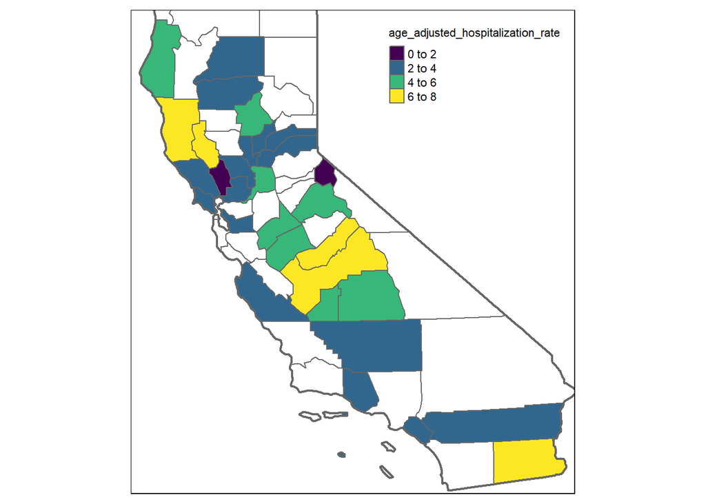

Map of California Counties and Age-Adjusted Hospitalization Rate for Hispanic Individuals

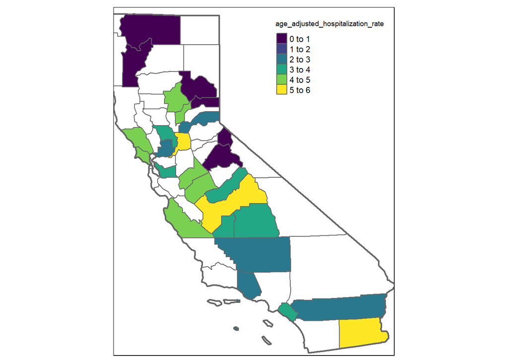

Map of California Counties and Age-Adjusted Hospitalization Rate for Black Individuals

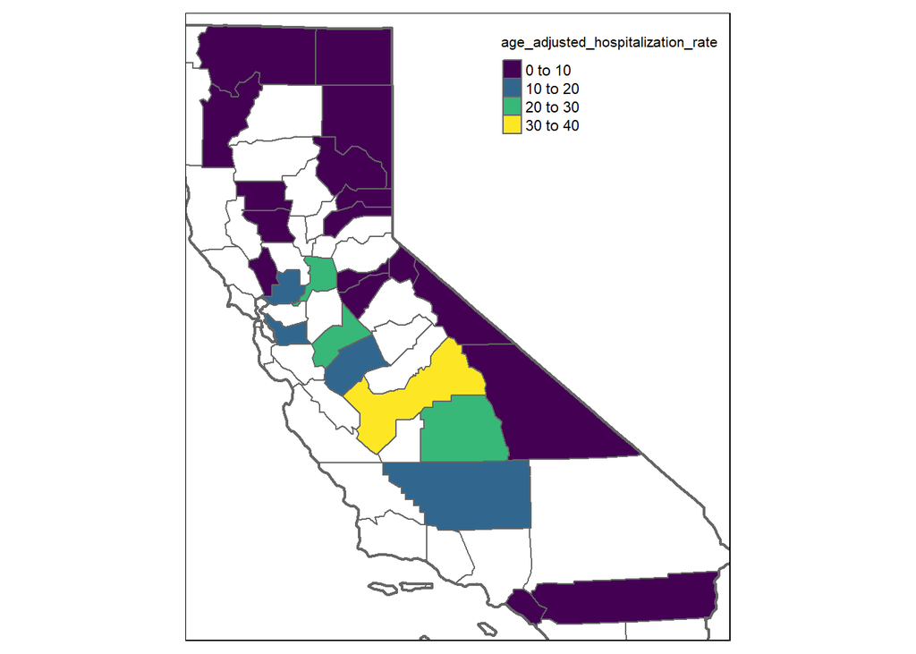

As seen from the map legends, the age-adjusted hospitalization rates for Black individuals have a much higher range overall. The maps for White and Hispanic individuals have highest rates in the ranges 5 to 6 and 6 to 8, whereas the highest range for Black individuals is 30 to 40. Therefore, these maps highlight the health disparity for Black individuals in California based on their disproportionately high rates of asthma hospitalization compared to their White and Hispanic counterparts.

Additionally, from all of these maps, Fresno County (the yellow county in the center of the state) pops out as a county of interest yet again, as it has the highest asthma hospitalization rate for each race/ethnicity group. Imperial County (at the very bottom of the state) appears to have a high asthma hospitalization rate compared to other counties.

Overall, we conclude that differences in age and racial group do correlate with differences in asthma hospitalization levels across California county populations. Particularly, Black people’s disproportionately high rates of asthma merit further study into the root causes of this health disparity.